# Assignment IV

Shailesh Dudala

February 27, 2019

> Please submit your answers by 5.59 pm Monday March 4, 2019

## Question 1: Prediction using Logistic Regression

We are going to perform perdiction on a voting dataset (files->assignments->assignment_4). The dataset contains the party affliation of 435 congressional members along with voting record on 16 issues that were put to vote in a single year. The party affliation is indicated as a binary variable as a 1 if the congress-person was a member of the ‘A’ party and 0 otherwise. The vote is indicated as 1 (if the member voted yes) and 0 (if ithe member voted no).

1. You will notice that the class-split is fairly even in the dataset.

0 : 168 members 1 : 267 members

Using caret, create a rough 80-20 split of the dataset into training and testing. In other words, 80% of the data should comprise the training dataset and 20% of the data should comprise the testing dataset. Ensure that the class membership is even (in other words, the proportion of 1 and 0 in both training and testing should be the approximately the same)

```r
# Attaching packages
library(caret)
library(pROC)
library(readr)
library(plyr)
library(dplyr)
library(jpeg)
```

NOTE: Set the seed to 476

```r
#Load dataset
d.vote <- read_csv("data_votes.csv")

#Check for NA values
d.vote = na.omit(d.vote)
```

```r
set.seed(476)
trainIndex <- createDataPartition(d.vote$party_A, p = 0.8, times = 1, list = FALSE)
d.train <- d.vote[trainIndex,]
d.test  <- d.vote[-trainIndex,]
```

2. Perform a logistic regression (using glm) on the training dataset and perform a prediction on the test dataset.

```r
#GLM
glm.out <- glm(d.train, formula = party_A ~., family = "binomial")
d.test$pred_A <- predict.glm(glm.out, newdata = d.test, type = "response")
```

3. Fill the confusion matrix below using your predictions. Consider outcome 1 as being “positive” and a probability cutoff of 0.5 (i.e. if probability >= 0.5, assign the label 1).

```r
#Assigning Class Labels
d.test$pred_A <- ifelse(d.test$pred_A >= 0.5, 1, 0)
#d.test <- d.test %>%  mutate(pred_A = as.factor(pred_A))
```

[output not shown]

4. Calculate the following: Sensitivity, Specificity, Positive Predictive Value, Negative Predictive Value, False Positive Rate, and Accuracy.

```
## Confusion Matrix and Statistics
##
##          Actual
## Predicted  0  1
##         0 29  4
##         1  2 52
##
##                Accuracy : 0.931
##                  95% CI : (0.8559, 0.9743)
##     No Information Rate : 0.6437
##     P-Value [Acc > NIR] : 3.77e-10
##
##                   Kappa : 0.8518
##  Mcnemar's Test P-Value : 0.6831
##
##             Sensitivity : 0.9355
##             Specificity : 0.9286
##          Pos Pred Value : 0.8788
##          Neg Pred Value : 0.9630
##              Prevalence : 0.3563
##          Detection Rate : 0.3333
##    Detection Prevalence : 0.3793
##       Balanced Accuracy : 0.9320
##
##        'Positive' Class : 0
##
```

```
## The Sensitivity is 0.9354839
```

```
## The Specificity is 0.9285714
```

```
## The Positive Predictive Value is 0.8787879
```

[output not shown]

```
## The Accuracy is 0.9310345
```

```
## The False Positvive Rate is 0.07142857
```

5. Calculate AUC (with 95% CI) using predicted probabilities

```r
# Changing class labels back to probabilities
d.test$pred_A <- predict.glm(glm.out, newdata = d.test, type = "response")
# Create a prediction object
pred <- roc(response = d.test$party_A, predictor = d.test$pred_A, direction = "<")
# Get AUC performance
auc_perf <- auc(pred)
auc_perf
```

```
## Area under the curve: 0.9879
```

```r
# Get 95% CI
ci_auc_perf <- ci.auc(pred)
ci_auc_perf
```

```
## 95% CI: 0.9715-1 (DeLong)
```

## Question 2: Cross-validation

Write a program that will perform 3-fold cross-validation (using the caret package) on the above train dataset. Calculate AUC (with 95% CI) on the test dataset.

NOTE : Set your seed as 156

```r
#Set Seed.
set.seed(156)
# Training using GLM
# 3-fold CV
training_params <- trainControl(method="cv", number = 3)
m.train.glm <- train(as.factor(party_A) ~ ., data = d.train, method = "glm", trControl = training_params)
m.train.glm
```

```
## Generalized Linear Model
##
## 348 samples
##  16 predictor
##   2 classes: '0', '1'
##
## No pre-processing
## Resampling: Cross-Validated (3 fold)
## Summary of sample sizes: 233, 231, 232
## Resampling results:
##
##   Accuracy   Kappa
##   0.9538968  0.9036769
```

```r
#summary(m.train.glm)


yhat_glm <- predict(m.train.glm, newdata = d.test, type = "prob")
# Create a prediction object
glm.pred <- roc(predictor = yhat_glm[,2], response = d.test$party_A, direction = "<")
# Get performance
auc.perf <- auc(glm.pred)
ci.auc.perf <- ci.auc(glm.pred)
auc.perf
```

```
## Area under the curve: 0.9879
```

```r
ci.auc.perf
```

```
## 95% CI: 0.9715-1 (DeLong)
```

## Question 3: Hierarchical clustering

We are going to use the USArrests dataset. Load this using the following command

```r
d.in <- data.frame(USArrests)
```

1. Perform hierarchical clustering using average linkage and Euclidean distance. Write the code and show the plots below.

Ans.

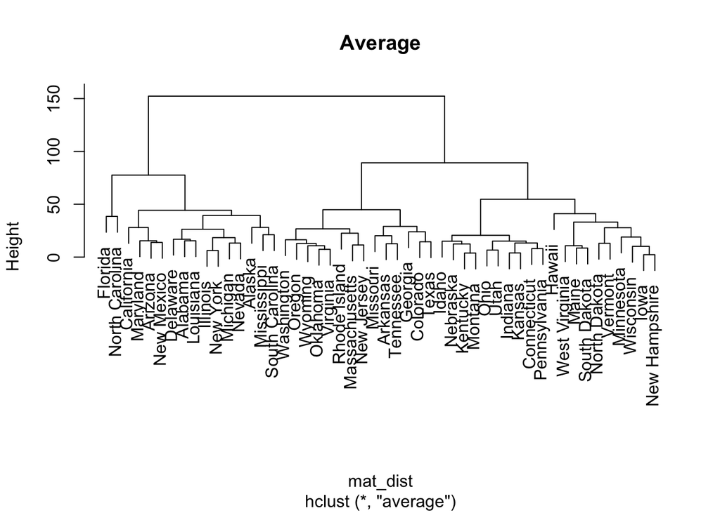

```r
#Calculate dist matrix and pass into hclust with average linkage as the method
mat_dist = dist(d.in, method = "euclidean")
hc.avg <- hclust(d = mat_dist, method = "average")
plot(hc.avg, main = "Average")
```

2. Perform hierarchical clustering using complete linkage and Euclidean distance, after scaling the variables to have a standard deviation of one. Write the code and show the plots below.

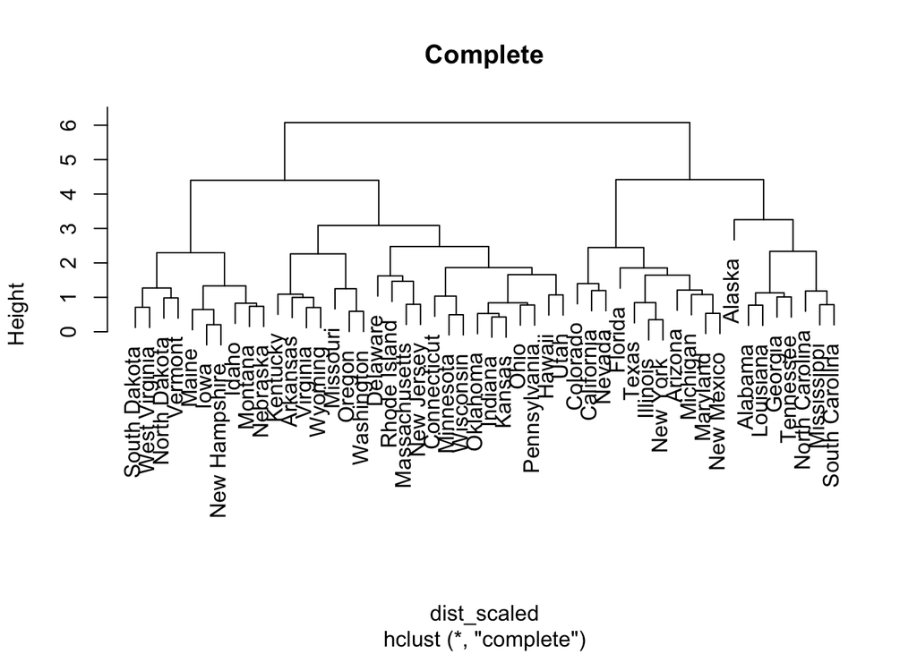

```r
#Calculate the scaled dist matrix and pass into hclust with comeplete linkage as the method
d.scaled <- scale(d.in)
dist_scaled <- dist(d.scaled)
hc.comp <- hclust(d = dist_scaled, method = "complete")

plot(hc.comp, main = "Complete")
```

## Question 4: K-means clustering

Download the dataset kmeans_data.csv (Files->Assignments->Assignment_4). The dataset contains randomly generated 100 observations of 2 variables, viz., X1 and X2

1. Plot X1 vs. X2 (i.e. X1 on the x-axis) as a scatter-plot. Write the code below.

```r
#Visualizing data
d.inn <- read_csv("kmeans_data.csv")
```

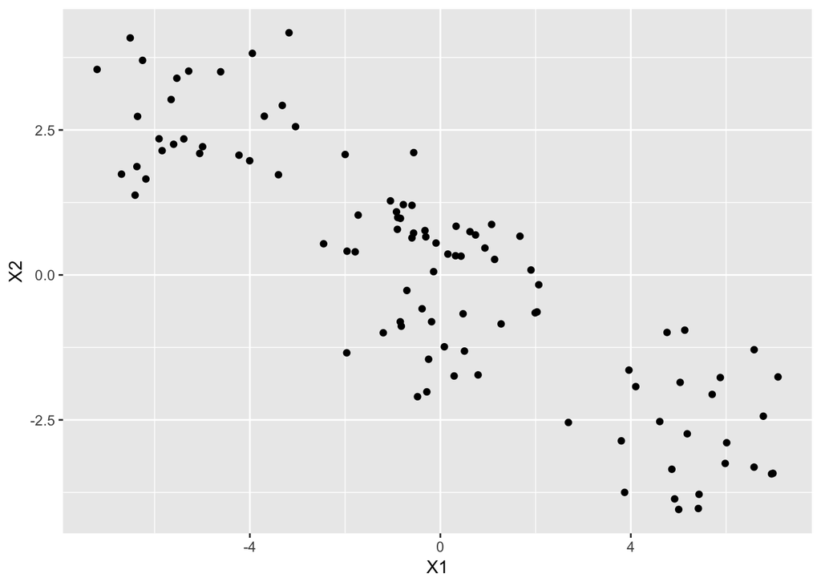

```r
ggplot(d.inn, aes(x = X1, y = X2)) + geom_point()
```

2. Perform a k-means clustering with $K$ = 3. Overlap the cluster labels on the scatter plot.

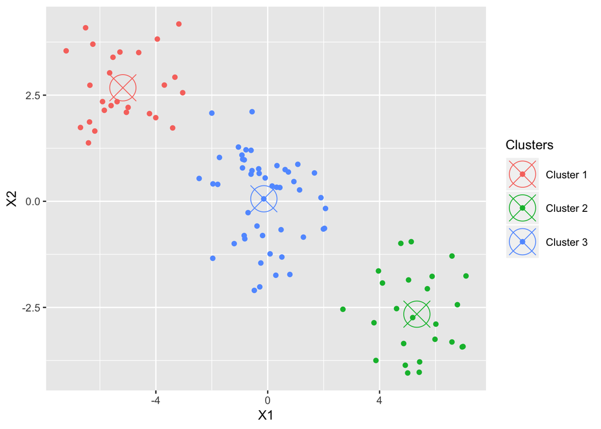

```r
#kmeans with 3 clusters
km.3 <- kmeans(x = d.inn, centers = 3, nstart = 1)
#Plotting clusters along with each of their centroids
centroids <- data.frame(cluster = factor(seq(1:3)), X1 = km.3$centers[,'X1'], X2 = km.3$centers[,'X2'])

p <- ggplot(d.inn, aes(x = X1, y = X2, color = as.factor(km.3$cluster))) + geom_point()
p <- p + scale_color_discrete(name = "Clusters", breaks = c(1, 2,3), labels = c("Cluster 1", "Cluster 2", "Cluster 3"))
p + geom_point(data = centroids, mapping = aes(x = X1, y = X2, color = cluster), size = 10,pch = 13)
```

3. Perform a k-means clustering with $K$ = 4. Overlap the cluster labels on the scatter plot.

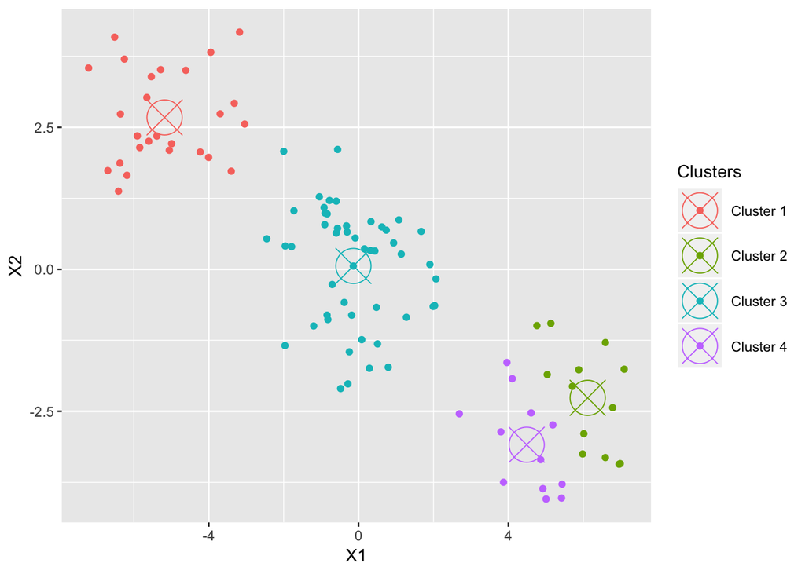

```r
# Insert code
km.4 <- kmeans(x = d.inn, centers = 4, nstart = 1)
#Plotting clusters along with each of their centroids
centroids_4 <- data.frame(cluster = factor(seq(1:4)), X1 = km.4$centers[,'X1'], X2 = km.4$centers[,'X2'])

p4 <- ggplot(d.inn, aes(x = X1, y = X2, colour = as.factor(km.4$cluster))) + geom_point()
p4 <- p4 + scale_color_discrete(name = "Clusters", breaks = c(1, 2,3, 4), labels = c("Cluster 1", "Cluster 2", "Cluster 3", "Cluster 4"))
p4 + geom_point(data = centroids_4, mapping = aes(x = X1, y = X2, color = cluster), size = 10,pch = 13)
```

4. Which is a better $K$?  
   Ans. k=3

## Question 5: Similarity Metrics

You are given the the following distance matrix that describes the euclidean distance between cities.

| Table | BOS | NY | DC | CHI |
| --- | --- | --- | --- | --- |
| BOS | 0 | 206 | 429 | 963 |
| NY | 206 | 0 | 233 | 802 |
| DC | 429 | 233 | 0 | 671 |
| CHI | 963 | 802 | 671 | 0 |

You are asked to perform a hierarchical clustering using single linkage.

The nearest pair of cities is BOS and NY, at distance 206.

1. Re-calculate the distance-matrix based on the merged group BOS/NY.

Ans.

| Table | (BOS, NY) | DC | CHI |
| --- | --- | --- | --- |
| (BOS, NY) | 0 | ? | ? |
| DC | ? | 0 | 671 |
| CHI | ? | 671 | 0 |

```r
d_BOSNY_DC <- min(429,233)
d_BOSNY_DC
```

```
## [1] 233
```

```r
d_BOSNY_CHI <- min(963,802)
d_BOSNY_CHI
```

```
## [1] 802
```

| Table | (BOS, NY) | DC | CHI |
| --- | --- | --- | --- |
| (BOS, NY) | 0 | 233 | 802 |
| DC | 233 | 0 | 671 |
| CHI | 802 | 671 | 0 |

2. Perform hierarchical clustering manually on paper (not using R code) until you reach two clusters. Show step-wise distance matrix calculations.

Ans.

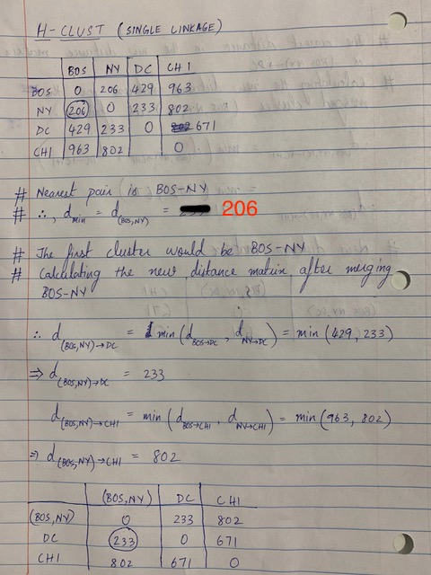

Part 1

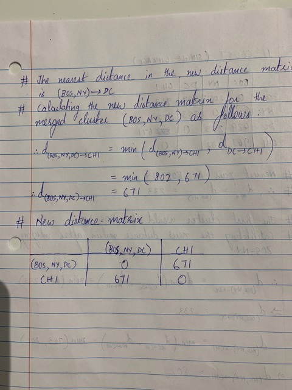

Part 2